# Attempts at Connecting Fluctuations in the Gut Microbiome with the Development of Human Hepatocellular Carcinoma

# 5 Data Visualization, Part 1

## 5.1 Run a PCA plot

```r
vstcounts <- vst(dds, blind = FALSE)
```

```r
#pdf(file = "PCA_plot_TNT_RNAseq.pdf", height = 6, width = 6)
pcaData <- plotPCA(vstcounts, intgroup=c("condition"), returnData=TRUE)
```

```
## using ntop=500 top features by variance
```

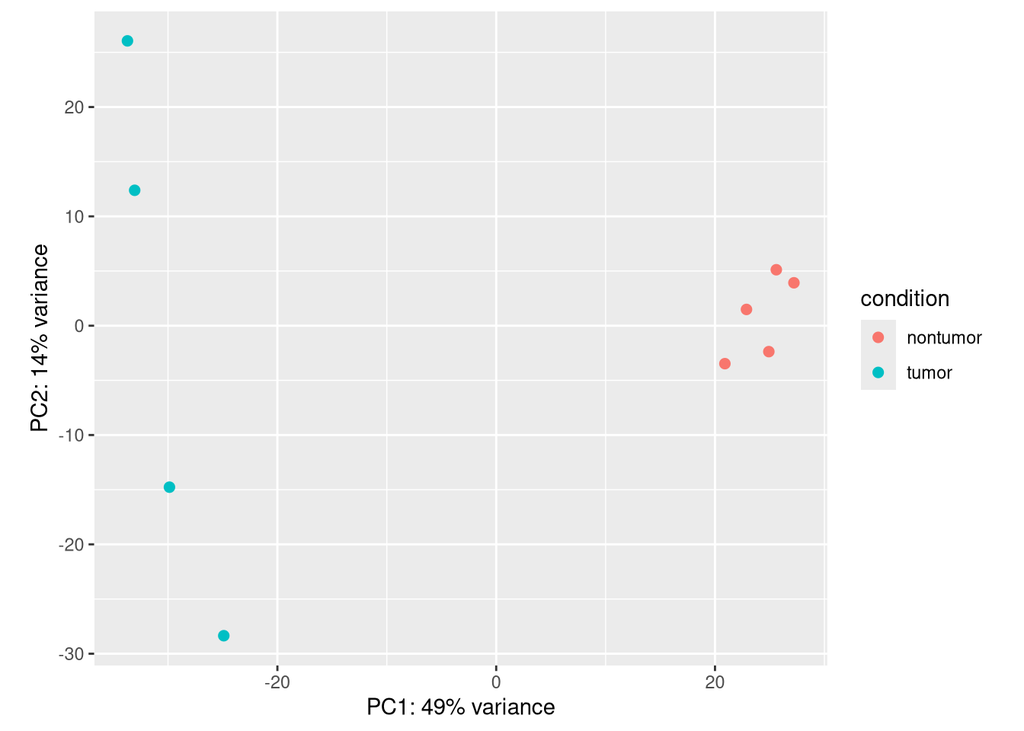

```r
percentVar <- round(100 * attr(pcaData, "percentVar"))

ggplot(pcaData, aes(PC1, PC2, color=condition)) +
  geom_point(size=2) +
  xlab(paste0("PC1: ",percentVar[1],"% variance")) +
  ylab(paste0("PC2: ",percentVar[2],"% variance")) +
  coord_fixed()
```

```r
#dev.off()
```

Figure 1: PCA plot of the variance in our samples. Nontumor samples (red) cluster nicely to the rightmost side of the plot. Less clustering is observed among the tumor samples (blue), which is to be expected as tumor involve many mutations, randomly “generated” from a millions of potential genome errors. Our tumor samples cluster to the leftmost side of the plot. Differences among the tumor samples only account for 14% of the total variance among all samples. We will continue to see the lack of strong clustering among the tumor samples reflected in later figures.

## 5.2 Generate a correlation heatmap

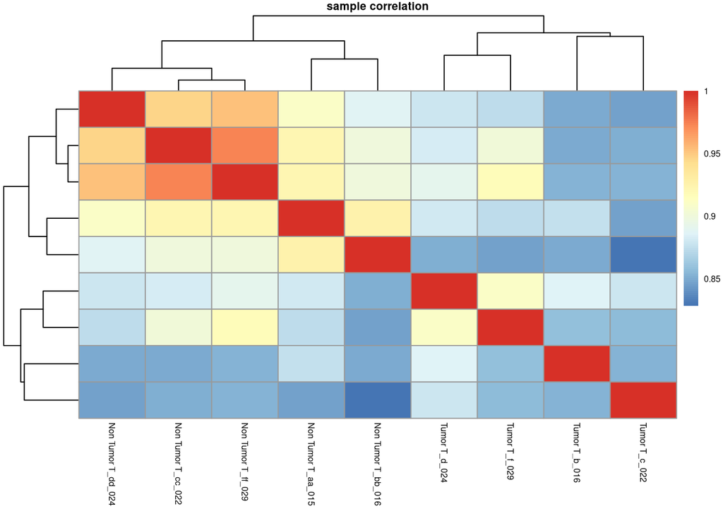

```r
#pdf(file = "correlation_plot_TNT_RNAseq.pdf", height = 3, width = 4)

vst_mat <- assay(vstcounts)
vst_cor <- cor(vst_mat)

#annotation_heatmap <- data.frame(row.names=colnames(vst_mat), condition)

cor_heatmap <- as.ggplot(pheatmap(vst_cor,
                                  main = "sample correlation",
                                  show_rownames = F,
                                  show_colnames = T,
                                  fontsize = 6,
                                  fontsize_col = 6,
                                  fontsize_row = 6,
                                  width = 3,
                                  height = 4))
```

```r
#dev.off()
```

Figure 2: Correlation heatmap of our samples. Correlation values range from about 0.8 (dark blue) to 1 (red). Correlation across samples is higher among nontumor samples than among tumor samples and between tumor and nontumor samples. This is expected as nontumor or healthy samples will have greater similarity among themselves, being normal healthy liver cells, than the tumor samples which have many random mutations each.

# 6 Post-Processing, Part 1

## 6.1 Compare and Contrast

```r
# How does gene regulation differ between the tumor and nontumor sample groups?
tum_non_res <- results(dds, contrast = c("condition", "tumor", "nontumor"))

head(tum_non_res)
```

```
## log2 fold change (MLE): condition tumor vs nontumor
## Wald test p-value: condition tumor vs nontumor
## DataFrame with 6 rows and 6 columns
##                  baseMean log2FoldChange     lfcSE      stat      pvalue
##                 <numeric>      <numeric> <numeric> <numeric>   <numeric>
## ENSG00000000003  308.1936     -0.6819711  0.422167 -1.615406 0.106222835
## ENSG00000000419   80.5779      0.2445667  0.384466  0.636121 0.524697655
## ENSG00000000457   44.9737      0.4179315  0.496099  0.842436 0.399543771
## ENSG00000000460   11.9269      1.7969929  0.720096  2.495492 0.012578261
## ENSG00000000938   25.3287     -2.1209641  0.554476 -3.825172 0.000130681
## ENSG00000000971 1059.5147      0.0813659  0.579654  0.140370 0.888367936
##                       padj
##                  <numeric>
## ENSG00000000003 0.36659696
## ENSG00000000419 0.78699770
## ENSG00000000457 0.70652193
## ENSG00000000460 0.10659155
## ENSG00000000938 0.00425914
## ENSG00000000971 0.96306692
```

## 6.2 Merge results

```r
tum_non_res <- merge(as.data.frame(tum_non_res),
                 as.data.frame(counts(dds, normalized=TRUE)),
                 by="row.names",
                 sort=FALSE)

names(tum_non_res)[1] <- "Gene_id"

str(tum_non_res)
```

```
## 'data.frame':    23258 obs. of  16 variables:
##  $ Gene_id           : 'AsIs' chr  "ENSG00000000003" "ENSG00000000419" "ENSG00000000457" "ENSG00000000460" ...
##  $ baseMean          : num  308.2 80.6 45 11.9 25.3 ...
##  $ log2FoldChange    : num  -0.682 0.245 0.418 1.797 -2.121 ...
##  $ lfcSE             : num  0.422 0.384 0.496 0.72 0.554 ...
##  $ stat              : num  -1.615 0.636 0.842 2.495 -3.825 ...
##  $ pvalue            : num  0.106223 0.524698 0.399544 0.012578 0.000131 ...
##  $ padj              : num  0.3666 0.787 0.70652 0.10659 0.00426 ...
##  $ Tumor T_b_016     : num  122.62 94.32 27.25 14.67 5.24 ...
##  $ Tumor T_c_022     : num  128.68 117.49 39.16 33.57 5.59 ...
##  $ Tumor T_d_024     : num  291.8 79.7 58 12.9 11.2 ...
##  $ Tumor T_f_029     : num  373.1 70.4 83.2 21.8 10.5 ...
##  $ Non Tumor T_aa_015: num  354.27 44.56 24.51 2.23 57.93 ...
##  $ Non Tumor T_bb_016: num  250.7 59.4 46.2 0 46.2 ...
##  $ Non Tumor T_cc_022: num  394.7 105 50.4 4.2 31.1 ...
##  $ Non Tumor T_dd_024: num  437.67 75.69 26.33 9.87 16.45 ...
##  $ Non Tumor T_ff_029: num  420.21 78.63 49.68 8.05 43.8 ...
```

## 6.3 Sort changes in gene expression by up-regulation, down-regulation, or unchanged

```r
#Add a column to dataframe to specify up or down regulated
tum_non_res$diffexpressed <- "Unchanged"

#if log2FC > 1 and padj < 0.05 set as upregulated
tum_non_res$diffexpressed[tum_non_res$padj < 0.05 & tum_non_res$log2FoldChange > 1] <- "Upregulated"

#if log2FC > -1 and padj < 0.05 set as downregulated
tum_non_res$diffexpressed[tum_non_res$padj < 0.05 & tum_non_res$log2FoldChange < -1] <- "Downregulated"

str(tum_non_res)
```

```
## 'data.frame':    23258 obs. of  17 variables:
##  $ Gene_id           : 'AsIs' chr  "ENSG00000000003" "ENSG00000000419" "ENSG00000000457" "ENSG00000000460" ...
##  $ baseMean          : num  308.2 80.6 45 11.9 25.3 ...
##  $ log2FoldChange    : num  -0.682 0.245 0.418 1.797 -2.121 ...
##  $ lfcSE             : num  0.422 0.384 0.496 0.72 0.554 ...
##  $ stat              : num  -1.615 0.636 0.842 2.495 -3.825 ...
##  $ pvalue            : num  0.106223 0.524698 0.399544 0.012578 0.000131 ...
##  $ padj              : num  0.3666 0.787 0.70652 0.10659 0.00426 ...
##  $ Tumor T_b_016     : num  122.62 94.32 27.25 14.67 5.24 ...
##  $ Tumor T_c_022     : num  128.68 117.49 39.16 33.57 5.59 ...
##  $ Tumor T_d_024     : num  291.8 79.7 58 12.9 11.2 ...
##  $ Tumor T_f_029     : num  373.1 70.4 83.2 21.8 10.5 ...
##  $ Non Tumor T_aa_015: num  354.27 44.56 24.51 2.23 57.93 ...
##  $ Non Tumor T_bb_016: num  250.7 59.4 46.2 0 46.2 ...
##  $ Non Tumor T_cc_022: num  394.7 105 50.4 4.2 31.1 ...
##  $ Non Tumor T_dd_024: num  437.67 75.69 26.33 9.87 16.45 ...
##  $ Non Tumor T_ff_029: num  420.21 78.63 49.68 8.05 43.8 ...
##  $ diffexpressed     : chr  "Unchanged" "Unchanged" "Unchanged" "Unchanged" ...
```

```r
tum_non_full_matrix <- read.csv(file = "Tumor_Vs_Nontumor_full_matrix_042225.csv",
                                header = TRUE)

tum_non_full_matrix <- tibble(tum_non_full_matrix)
# changed data_frame() to tibble()
```